# Desarrollo Humano Argentina, Colombia, España y Venezuela (1990-2023)

Autor/a

Arnaldo Di Remigio

## Tabla: Índice de Desarrollo Humano para Argentina, Colombia, España y Venezuela

|  | entity_name | year | hdi__sex_total | clasificacion_indice |
| --- | --- | --- | --- | --- |
| 1 | Argentina | 1990 | 0.733 | bajo_indice |
| 2 | Argentina | 1991 | 0.739 | bajo_indice |
| 3 | Argentina | 1992 | 0.743 | bajo_indice |
| 4 | Argentina | 1993 | 0.748 | bajo_indice |
| 5 | Argentina | 1994 | 0.753 | bajo_indice |
| 6 | Argentina | 1995 | 0.754 | bajo_indice |
| 7 | Argentina | 1996 | 0.76 | bajo_indice |
| 8 | Argentina | 1997 | 0.768 | bajo_indice |
| 9 | Argentina | 1998 | 0.772 | bajo_indice |
| 10 | Argentina | 1999 | 0.783 | alto_indice |

[output cut: 126 more lines]

## Distribución de observaciones por país

Todos los paises tienen la misma cantidad de observaciones en el estudio, 34 para ser exactos.

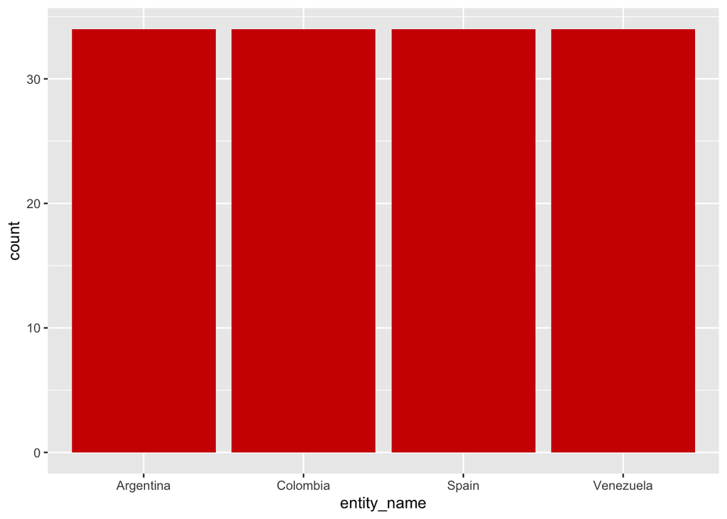

## Variabilidad del Índice de Desarrollo Humano (IDH) por país

España alcanza los valores más altos (0.8-0.9), mientras que Colombia y Venezuela presentan una distribución similar en el rango 0.7-0.8, y Argentina se sitúa entre 0.75 y 0.85

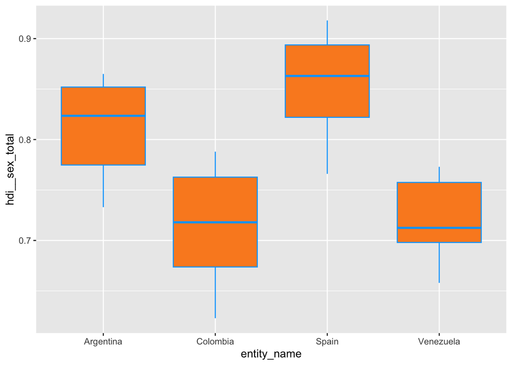

## Distribución del IDH total

La mayoría de los valores del Índice de Desarrollo Humano (IDH) se concentran alrededor de 0.75, con una frecuencia superior a 30, indicando que este rango es el más común entre los datos analizados

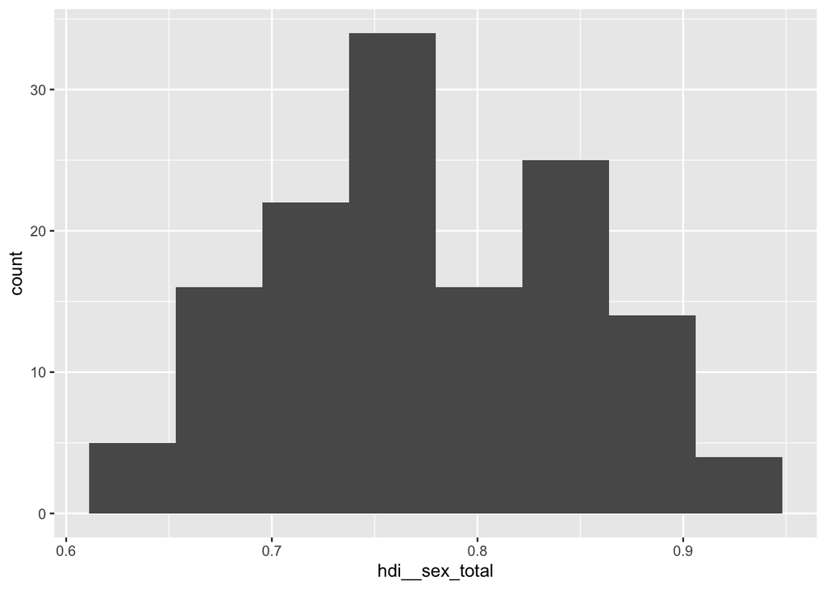

## Distribución del IDH por país

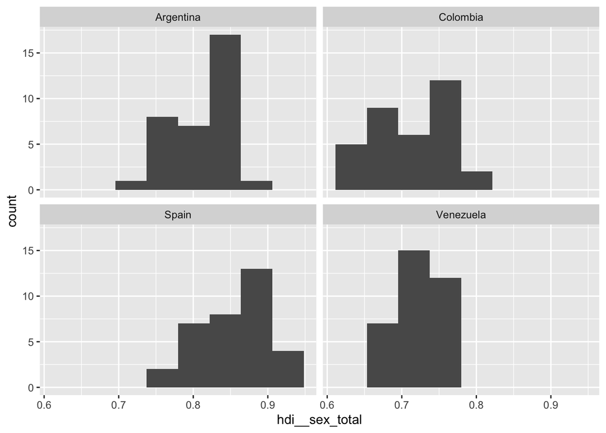

## Densidad del IDH por país

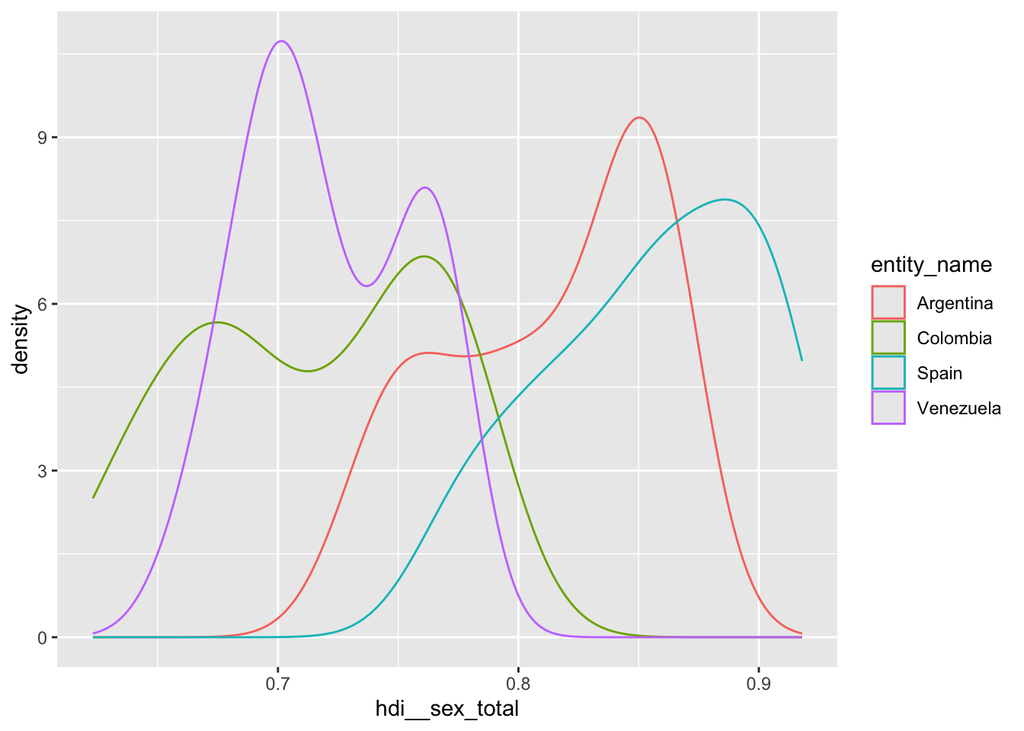

## Evolución del IDH a lo largo del tiempo por país

España tiene el IDH más alto y estable, Argentina sigue con una tendencia de crecimiento, mientras que Colombia y Venezuela tienen fluctuaciones, con Venezuela mostrando una caída reciente

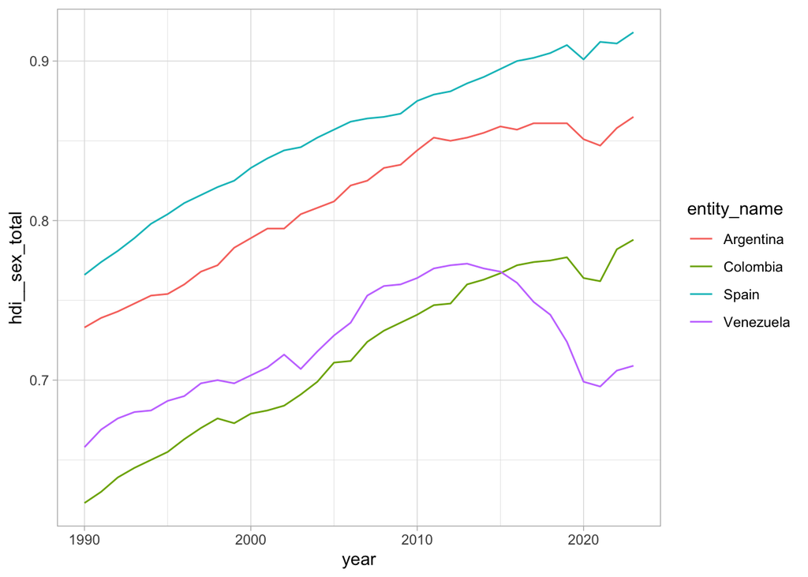

## Maximos de IDH por país

Máximo Índice de Desarrollo Humano (IDH) por País

| Año | Max_HDI |
| --- | --- |
| Argentina |  |
| 2023 | 0.865 |
| Colombia |  |
| 2023 | 0.788 |
| Spain |  |
| 2023 | 0.918 |
| Venezuela |  |
| 2013 | 0.773 |

Fuente: Datos de Desarrollo Humano (owidapi)